# Solaris Analytics

### **ADS508 | Group 7 | Authors: Luigi Salemi, Francisco Hernandez**

### This notebook covers ingestion and EDA for all primary datasets:

[output not shown]

**S3 Bucket:** `s3://solaris-analytics-bucket/`  
**GitHub:** https://github.com/darth-franky/Applied-Data-Science/tree/main/ADS508

```python
import subprocess
subprocess.run(['pip', 'install', 'kagglehub', 'imbalanced-learn', '-q'])

import os
import json
import boto3
import sagemaker
import pandas as pd
import numpy as np
import matplotlib.pyplot as plt
import matplotlib.image as mpimg
import seaborn as sns
import kagglehub
from pathlib import Path

from sklearn.preprocessing import StandardScaler, LabelEncoder
from sklearn.model_selection import train_test_split
from sklearn.metrics import classification_report, confusion_matrix, f1_score, mean_squared_error
from imblearn.over_sampling import SMOTE

from sagemaker import get_execution_role, image_uris
from sagemaker.serializers import CSVSerializer
from sagemaker.inputs import TrainingInput
from sagemaker.estimator import Estimator

session = sagemaker.Session()
s3 = boto3.client('s3')
role = sagemaker.get_execution_role()

REGION = session.boto_region_name
BUCKET = 'solaris-analytics-bucket'
IMAGE_EXTENSIONS = {'.jpg', '.jpeg', '.png', '.bmp', '.tiff'}

print(f'SageMaker Role: {role}')
print(f'S3 Bucket: s3://{BUCKET}/')
```

```
sagemaker.config INFO - Not applying SDK defaults from location: /etc/xdg/sagemaker/config.yaml
sagemaker.config INFO - Not applying SDK defaults from location: /home/sagemaker-user/.config/sagemaker/config.yaml
SageMaker Role: arn:aws:iam::187806919439:role/LabRole
S3 Bucket: s3://solaris-analytics-bucket/
```

```python
response = s3.list_objects_v2(Bucket=BUCKET)
objects = response.get('Contents', [])
print(f'Total objects in bucket: {len(objects)}')
```

```
Total objects in bucket: 1000
```

## 1. Ingest Houston Solar Irradiance Dataset (NREL NSRDB) from S3

**File:** `Houston_Solar_2000_2019.csv`  
**S3 path:** `s3://solaris-analytics-bucket/Houston_Solar_2000_2019.csv`  
**Key fields:** `Timestamp`, `GHI`, `DNI`, `DHI`, `Temperature`, `Wind_Speed`  
**Records:** ~350,000 rows at 30-min intervals (2000-2019)

```python
import os

# Create folder
os.makedirs('/home/sagemaker-user/dataset1', exist_ok=True)

# Set paths
nsrdb_s3_key = 'Houston_Solar_2000_2019.csv'
nsrdb_local  = '/home/sagemaker-user/dataset1/Houston_Solar_2000_2019.csv'

# Download from S3
print(f'Downloading s3://{BUCKET}/{nsrdb_s3_key} ...')
s3.download_file(BUCKET, nsrdb_s3_key, nsrdb_local)
print('Download complete.')

# Load into DataFrame
nsrdb_df = pd.read_csv(nsrdb_local, parse_dates=['Timestamp'])
print(f'Shape: {nsrdb_df.shape}')
nsrdb_df.head()
```

```
Downloading s3://solaris-analytics-bucket/Houston_Solar_2000_2019.csv ...
Download complete.
Shape: (350640, 6)
```

|  | Timestamp | GHI | DNI | DHI | Temperature | Wind_Speed |
| --- | --- | --- | --- | --- | --- | --- |
| 0 | 2000-01-01 00:00:00 | 0 | 0 | 0 | 11.9 | 0.7 |
| 1 | 2000-01-01 00:30:00 | 0 | 0 | 0 | 11.5 | 0.7 |
| 2 | 2000-01-01 01:00:00 | 0 | 0 | 0 | 11.1 | 0.8 |
| 3 | 2000-01-01 01:30:00 | 0 | 0 | 0 | 10.6 | 0.9 |
| 4 | 2000-01-01 02:00:00 | 0 | 0 | 0 | 10.1 | 1.0 |

### 1.1 NSRDB — Basic Info & Missing Values

```python
print('=== Data Types ===')
print(nsrdb_df.dtypes)

print('\n=== Missing Values ===')
missing = nsrdb_df.isnull().sum()
print(missing[missing > 0] if missing.sum() > 0 else 'No missing values found.')

print('\n=== Descriptive Statistics ===')
display(nsrdb_df.describe().T)
```

```
=== Data Types ===
Timestamp      datetime64[ns]
GHI                     int64
DNI                     int64
DHI                     int64
Temperature           float64
Wind_Speed            float64
dtype: object

=== Missing Values ===
No missing values found.

=== Descriptive Statistics ===
```

|  | count | mean | min | 25% | 50% | 75% | max | std |
| --- | --- | --- | --- | --- | --- | --- | --- | --- |
| Timestamp | 350640 | 2009-12-31 11:45:00.000001024 | 2000-01-01 00:00:00 | 2004-12-31 05:52:30 | 2009-12-31 11:45:00 | 2014-12-31 17:37:30 | 2019-12-31 23:30:00 | NaN |
| GHI | 350640.0 | 201.67449 | 0.0 | 0.0 | 0.0 | 365.0 | 1078.0 | 287.283358 |
| DNI | 350640.0 | 197.567154 | 0.0 | 0.0 | 0.0 | 348.0 | 1045.0 | 313.197351 |
| DHI | 350640.0 | 79.42834 | 0.0 | 0.0 | 0.0 | 120.0 | 663.0 | 116.628882 |
| Temperature | 350640.0 | 20.82322 | -7.0 | 15.2 | 22.2 | 26.6 | 43.6 | 8.2369 |
| Wind_Speed | 350640.0 | 2.218328 | 0.2 | 1.3 | 2.0 | 2.9 | 10.7 | 1.128439 |

### 1.2 NSRDB — Irradiance & Weather Distributions

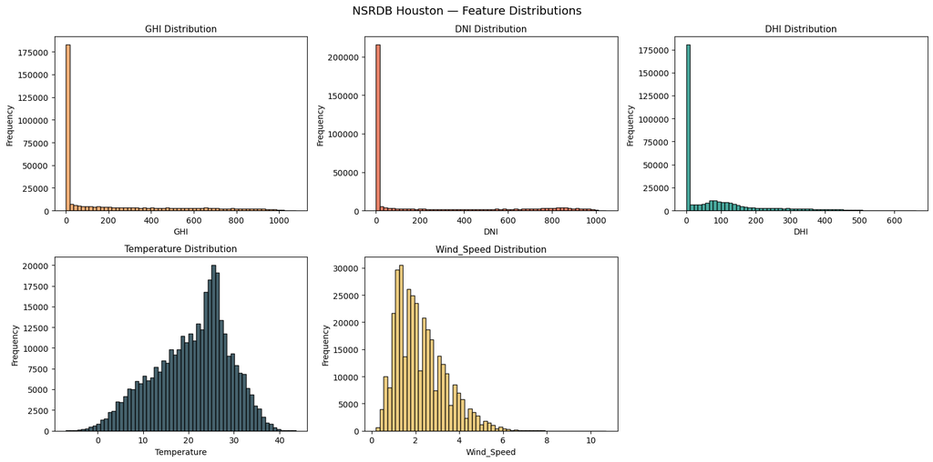

```
Note: High frequency of GHI=0 reflects nighttime — these rows may be filtered before forecasting.
```

```python
irradiance_cols = ['GHI', 'DNI', 'DHI']
weather_cols    = ['Temperature', 'Wind_Speed']
all_numeric     = irradiance_cols + weather_cols

fig, axes = plt.subplots(2, 3, figsize=(16, 8))
axes = axes.flatten()
colors = ['#F4A261', '#E76F51', '#2A9D8F', '#264653', '#E9C46A']

for i, col in enumerate(all_numeric):
    axes[i].hist(nsrdb_df[col].dropna(), bins=60, color=colors[i], edgecolor='black', alpha=0.85)
    axes[i].set_title(f'{col} Distribution', fontsize=11)
    axes[i].set_xlabel(col)
    axes[i].set_ylabel('Frequency')

axes[5].set_visible(False)
plt.suptitle('NSRDB Houston — Feature Distributions', fontsize=14)
plt.tight_layout()
plt.savefig('/tmp/nsrdb_distributions.png', dpi=150)
plt.show()
print('Note: High frequency of GHI=0 reflects nighttime — these rows may be filtered before forecasting.')
```

### 1.3 NSRDB — Seasonal & Temporal Bias Check

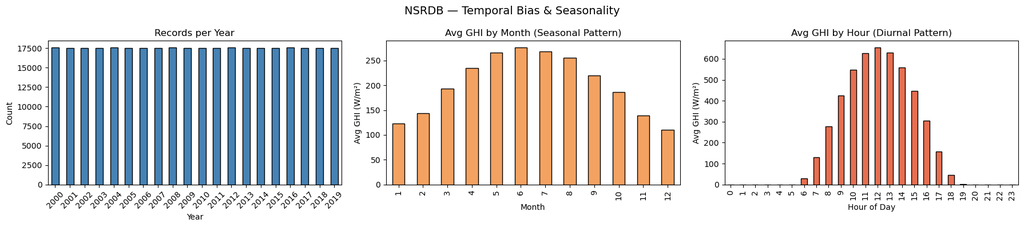

```
Note: NSRDB is U.S.-centric (Houston only). Seasonal and diurnal patterns are expected physical behavior.
```

```python
nsrdb_df['Year']  = nsrdb_df['Timestamp'].dt.year
nsrdb_df['Month'] = nsrdb_df['Timestamp'].dt.month
nsrdb_df['Hour']  = nsrdb_df['Timestamp'].dt.hour

fig, axes = plt.subplots(1, 3, figsize=(18, 4))

nsrdb_df['Year'].value_counts().sort_index().plot(
    kind='bar', ax=axes[0], color='steelblue', edgecolor='black')
axes[0].set_title('Records per Year')
axes[0].set_xlabel('Year')
axes[0].set_ylabel('Count')
axes[0].tick_params(axis='x', rotation=45)

nsrdb_df.groupby('Month')['GHI'].mean().plot(
    kind='bar', ax=axes[1], color='#F4A261', edgecolor='black')
axes[1].set_title('Avg GHI by Month (Seasonal Pattern)')
axes[1].set_xlabel('Month')
axes[1].set_ylabel('Avg GHI (W/m²)')

nsrdb_df.groupby('Hour')['GHI'].mean().plot(
    kind='bar', ax=axes[2], color='#E76F51', edgecolor='black')
axes[2].set_title('Avg GHI by Hour (Diurnal Pattern)')
axes[2].set_xlabel('Hour of Day')
axes[2].set_ylabel('Avg GHI (W/m²)')

plt.suptitle('NSRDB — Temporal Bias & Seasonality', fontsize=14)
plt.tight_layout()
plt.savefig('/tmp/nsrdb_temporal_bias.png', dpi=150)
plt.show()
print('Note: NSRDB is U.S.-centric (Houston only). Seasonal and diurnal patterns are expected physical behavior.')
```

### 1.4 NSRDB — GHI Irradiance Category Distribution

Per the design doc, GHI will be bucketed into **Low / Medium / High** for classification tasks.

```
=== GHI Category Distribution (daytime only) ===
GHI_Category
Medium    67793
Low       57143
High      50195
Name: count, dtype: int64
```

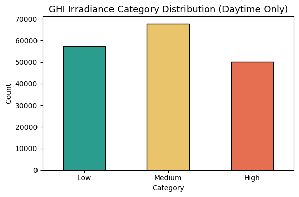

```python
daytime_df = nsrdb_df[nsrdb_df['GHI'] > 0].copy()
daytime_df['GHI_Category'] = pd.cut(
    daytime_df['GHI'],
    bins=[0, 200, 600, daytime_df['GHI'].max() + 1],
    labels=['Low', 'Medium', 'High']
)

print('=== GHI Category Distribution (daytime only) ===')
print(daytime_df['GHI_Category'].value_counts())

fig, ax = plt.subplots(figsize=(6, 4))
daytime_df['GHI_Category'].value_counts().reindex(['Low','Medium','High']).plot(
    kind='bar', ax=ax, color=['#2A9D8F','#E9C46A','#E76F51'], edgecolor='black'
)
ax.set_title('GHI Irradiance Category Distribution (Daytime Only)', fontsize=13)
ax.set_xlabel('Category')
ax.set_ylabel('Count')
ax.tick_params(axis='x', rotation=0)
plt.tight_layout()
plt.savefig('/tmp/nsrdb_ghi_categories.png', dpi=150)
plt.show()
```

### 1.5 NSRDB — Correlation Heatmap

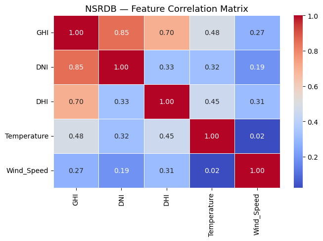

```python
fig, ax = plt.subplots(figsize=(7, 5))
sns.heatmap(nsrdb_df[all_numeric].corr(), annot=True, fmt='.2f', cmap='coolwarm', ax=ax, linewidths=0.5)
ax.set_title('NSRDB — Feature Correlation Matrix', fontsize=13)
plt.tight_layout()
plt.savefig('/tmp/nsrdb_correlation.png', dpi=150)
plt.show()
```

## 2. Ingest GPVS-Faults Sensor Dataset from S3

```python
response  = s3.list_objects_v2(Bucket=BUCKET)
gpvs_keys = [obj['Key'] for obj in response.get('Contents', [])]

local_gpvs_dir = '/home/sagemaker-user/dataset2/gpvs-faults/'
os.makedirs(local_gpvs_dir, exist_ok=True)

for key in gpvs_keys:
    filename = key.split('/')[-1]
    if filename:
        local_path = os.path.join(local_gpvs_dir, filename)
        s3.download_file(BUCKET, key, local_path)
        #print(f'Downloaded: {key}')

csv_files = list(Path(local_gpvs_dir).glob('*.csv')) + list(Path(local_gpvs_dir).glob('*.tsv'))
dfs = []
for f in csv_files:
    sep = '\t' if f.suffix == '.tsv' else ','
    df_temp = pd.read_csv(f, sep=sep)
    df_temp['source_file'] = f.name
    dfs.append(df_temp)
    print(f'Loaded {f.name}: {df_temp.shape}')

gpvs_df = pd.concat(dfs, ignore_index=True)
print(f'\nCombined GPVS shape: {gpvs_df.shape}')
gpvs_df.head()
```

```
Loaded F0L.csv: (143715, 15)
Loaded F0M.csv: (141014, 15)
Loaded F1L.csv: (129013, 15)
Loaded F1M.csv: (139014, 15)
Loaded F2L.csv: (142128, 15)
Loaded F2M.csv: (144015, 15)
Loaded F3L.csv: (103497, 15)
Loaded F3M.csv: (69967, 15)
Loaded F4L.csv: (144014, 15)
Loaded F4M.csv: (144014, 15)
Loaded F5L.csv: (143015, 15)
Loaded F5M.csv: (144014, 15)
Loaded F6L.csv: (144015, 15)
Loaded F6M.csv: (144015, 15)
Loaded F7L.csv: (144015, 15)
Loaded F7M.csv: (144015, 15)
Loaded Houston_Solar_2000_2019.csv: (350640, 7)

Combined GPVS shape: (2514120, 21)
```

|  | Time | Ipv | Vpv | Vdc | ia | ib | ic | va | vb | vc | ... | If | Vabc | Vf | source_file | Timestamp | GHI | DNI | DHI | Temperature | Wind_Speed |
| --- | --- | --- | --- | --- | --- | --- | --- | --- | --- | --- | --- | --- | --- | --- | --- | --- | --- | --- | --- | --- | --- |
| 0 | 0.000028 | 1.572327 | 101.348877 | 144.140625 | -0.135133 | 0.490112 | -0.354985 | 41.744537 | -149.872894 | 109.064585 | ... | 50.0 | 1.0 | 50.0 | F0L.csv | NaN | NaN | NaN | NaN | NaN | NaN |
| 1 | 0.000128 | 1.503265 | 101.458740 | 143.554688 | -0.108277 | 0.510254 | -0.388555 | 46.831512 | -150.716705 | 105.829976 | ... | 50.0 | 1.0 | 50.0 | F0L.csv | NaN | NaN | NaN | NaN | NaN | NaN |
| 2 | 0.000228 | 1.492859 | 101.574707 | 143.554688 | -0.168702 | 0.496826 | -0.334844 | 51.074677 | -152.018585 | 102.543132 | ... | 50.0 | 1.0 | 50.0 | F0L.csv | NaN | NaN | NaN | NaN | NaN | NaN |
| 3 | 0.000328 | 1.558136 | 101.312256 | 143.261719 | -0.135133 | 0.510254 | -0.361699 | 55.848236 | -152.585144 | 98.143260 | ... | 50.0 | 1.0 | 50.0 | F0L.csv | NaN | NaN | NaN | NaN | NaN | NaN |
| 4 | 0.000428 | 1.631927 | 101.141357 | 143.847656 | -0.202271 | 0.503540 | -0.321416 | 60.055237 | -152.609253 | 94.261729 | ... | 50.0 | 1.0 | 50.0 | F0L.csv | NaN | NaN | NaN | NaN | NaN | NaN |

5 rows × 21 columns

### 2.1 GPVS — Basic Info, Missing Values & Zero-Value Check

```python
print('=== Data Types ===')
print(gpvs_df.dtypes)

print('\n=== Missing Values ===')
missing = gpvs_df.isnull().sum()
print(missing[missing > 0] if missing.sum() > 0 else 'No missing values found.')

numeric_cols = gpvs_df.select_dtypes(include=[np.number]).columns.tolist()

print('\n=== Zero-Value Counts (potential sensor outage indicator) ===')
zero_counts = (gpvs_df[numeric_cols] == 0).sum()
zero_pct    = (zero_counts / len(gpvs_df) * 100).round(2)
print(pd.DataFrame({'Zero Count': zero_counts, 'Zero %': zero_pct}).to_string())
print('\nNote: High zero % in voltage/current/power may indicate sensor outages needing removal in data prep.')
```

```
=== Data Types ===
Time           float64
Ipv            float64
Vpv            float64
Vdc            float64
ia             float64
ib             float64
ic             float64
va             float64
vb             float64
vc             float64
Iabc           float64
If             float64
Vabc           float64
Vf             float64
source_file     object
Timestamp       object
GHI            float64
DNI            float64
DHI            float64
Temperature    float64
Wind_Speed     float64
dtype: object

=== Missing Values ===
Time            350640
Ipv             350640
Vpv             350640
Vdc             350640
ia              350640
ib              350640
ic              350640
va              350640
vb              350640
vc              350640
Iabc            350640
If              350640
Vabc            350640
Vf              350640
Timestamp      2163480
```

[output cut: 15 more lines]

```
ic                    0    0.00
va                   55    0.00
vb                   55    0.00
vc                    0    0.00
Iabc                  0    0.00
If                    0    0.00
Vabc                  0    0.00
Vf                    0    0.00
GHI              175509    6.98
DNI              195739    7.79
DHI              175509    6.98
Temperature          90    0.00
Wind_Speed            0    0.00

Note: High zero % in voltage/current/power may indicate sensor outages needing removal in data prep.
```

### 2.2 GPVS — Feature Distributions & Correlation

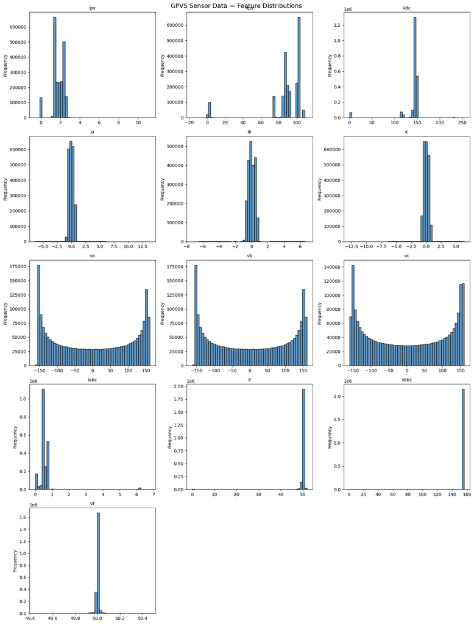

```python
plot_cols = [c for c in numeric_cols if c in
             ['Ipv','Vpv','Vdc','ia','ib','ic','va','vb','vc','Iabc','If','Vabc','Vf']]

n = len(plot_cols)
cols_per_row = 3
rows = (n + cols_per_row - 1) // cols_per_row

fig, axes = plt.subplots(rows, cols_per_row, figsize=(15, rows * 4))
axes = axes.flatten()

for i, col in enumerate(plot_cols):
    axes[i].hist(gpvs_df[col].dropna(), bins=50, color='steelblue', edgecolor='black', alpha=0.85)
    axes[i].set_title(col, fontsize=10)
    axes[i].set_ylabel('Frequency')

for j in range(i + 1, len(axes)):
    axes[j].set_visible(False)

plt.suptitle('GPVS Sensor Data — Feature Distributions', fontsize=14)
plt.tight_layout()
plt.savefig('/tmp/gpvs_distributions.png', dpi=150)
plt.show()
```

## 3. Ingest Image Datasets via KaggleHub → Upload to S3

Two image datasets downloaded from Kaggle and persisted to S3:

```python
def upload_dir_to_s3(local_dir, s3_prefix, bucket):
    """Recursively upload a local directory to an S3 prefix."""
    count = 0
    for root, _, files in os.walk(local_dir):
        for file in files:
            local_path = os.path.join(root, file)
            rel_path   = os.path.relpath(local_path, local_dir)
            s3_key     = s3_prefix + rel_path.replace(os.sep, '/')
            s3.upload_file(local_path, bucket, s3_key)
            count += 1
    return count

def count_images_by_class(base_path):
    """Return dict of {class_name: image_count} from a folder of class subfolders."""
    counts = {}
    for item in Path(base_path).iterdir():
        if item.is_dir():
            n = sum(1 for f in item.rglob('*') if f.suffix.lower() in IMAGE_EXTENSIONS)
            if n > 0:
                counts[item.name] = n
    return counts

print('Helper functions defined.')
```

```
Helper functions defined.
```

```python
# Download Solar Panel Images (pythonafroz)
print('Downloading pythonafroz/solar-panel-images ...')
solar_panel_path = kagglehub.dataset_download('pythonafroz/solar-panel-images')
print(f'Downloaded to: {solar_panel_path}')

n = upload_dir_to_s3(solar_panel_path, 'panel-images/solar-panel-images/', BUCKET)
print(f'Uploaded {n} files to s3://{BUCKET}/panel-images/solar-panel-images/')
```

```
Downloading pythonafroz/solar-panel-images ...
Downloaded to: /home/sagemaker-user/.cache/kagglehub/datasets/pythonafroz/solar-panel-images/versions/2
Uploaded 891 files to s3://solaris-analytics-bucket/panel-images/solar-panel-images/
```

```python
# Download PV Panel Defect Dataset (alicjalena)
print('Downloading alicjalena/pv-panel-defect-dataset ...')
pv_defect_path = kagglehub.dataset_download('alicjalena/pv-panel-defect-dataset')
print(f'Downloaded to: {pv_defect_path}')

n = upload_dir_to_s3(pv_defect_path, 'panel-images/pv-defect/', BUCKET)
print(f'Uploaded {n} files to s3://{BUCKET}/panel-images/pv-defect/')
```

```
Downloading alicjalena/pv-panel-defect-dataset ...
Downloaded to: /home/sagemaker-user/.cache/kagglehub/datasets/alicjalena/pv-panel-defect-dataset/versions/1
Uploaded 1574 files to s3://solaris-analytics-bucket/panel-images/pv-defect/
```

### 3.1 Solar Panel Images (pythonafroz) — Distribution & Samples

```
=== Solar Panel Images — Images per Class ===
  Faulty_solar_panel: 885 images
Total: 885
```

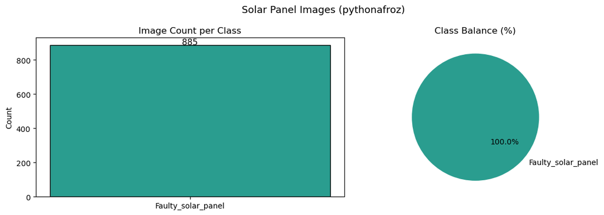

```python
solar_counts = count_images_by_class(solar_panel_path)
print('=== Solar Panel Images — Images per Class ===')
for cls, cnt in sorted(solar_counts.items()):
    print(f'  {cls}: {cnt} images')
print(f'Total: {sum(solar_counts.values())}')

fig, axes = plt.subplots(1, 2, figsize=(12, 4))

axes[0].bar(solar_counts.keys(), solar_counts.values(), color=['#2A9D8F','#E76F51'], edgecolor='black')
for i, (cls, cnt) in enumerate(solar_counts.items()):
    axes[0].text(i, cnt + 5, str(cnt), ha='center', fontsize=11)
axes[0].set_title('Image Count per Class', fontsize=12)
axes[0].set_ylabel('Count')

axes[1].pie(solar_counts.values(), labels=solar_counts.keys(),
            autopct='%1.1f%%', colors=['#2A9D8F','#E76F51'], startangle=140)
axes[1].set_title('Class Balance (%)', fontsize=12)

plt.suptitle('Solar Panel Images (pythonafroz)', fontsize=13)
plt.tight_layout()
plt.savefig('/tmp/solar_panel_distribution.png', dpi=150)
plt.show()
```

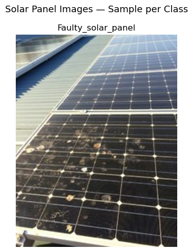

```python
# Sample one image per class
classes = sorted(solar_counts.keys())
fig, axes = plt.subplots(1, len(classes), figsize=(6 * len(classes), 5))
if len(classes) == 1:
    axes = [axes]

for ax, cls in zip(axes, classes):
    class_dir = Path(solar_panel_path) / cls
    imgs = [f for f in class_dir.rglob('*') if f.suffix.lower() in IMAGE_EXTENSIONS]
    if imgs:
        ax.imshow(mpimg.imread(str(imgs[0])))
        ax.set_title(cls, fontsize=12)
        ax.axis('off')

plt.suptitle('Solar Panel Images — Sample per Class', fontsize=13)
plt.tight_layout()
plt.savefig('/tmp/solar_panel_samples.png', dpi=150)
plt.show()
```

### 3.2 PV Panel Defect Dataset (alicjalena) — Distribution & Samples

```
=== PV Panel Defect Dataset — Images per Class ===
  test: 95 images
  train: 929 images
  val: 550 images
Total: 1574
```

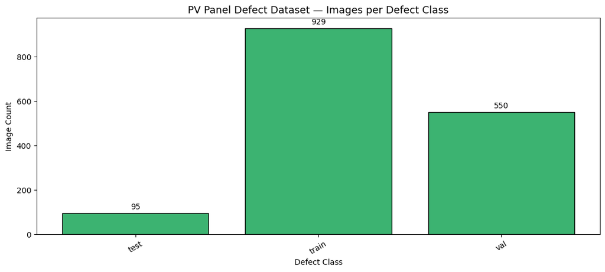

```
Note: Underrepresented defect classes will require augmentation or class weighting during CNN training.
```

```python
defect_counts = count_images_by_class(pv_defect_path)
print('=== PV Panel Defect Dataset — Images per Class ===')
for cls, cnt in sorted(defect_counts.items()):
    print(f'  {cls}: {cnt} images')
print(f'Total: {sum(defect_counts.values())}')

fig, ax = plt.subplots(figsize=(11, 5))
bars = ax.bar(defect_counts.keys(), defect_counts.values(), color='mediumseagreen', edgecolor='black')
ax.bar_label(bars, padding=3)
ax.set_title('PV Panel Defect Dataset — Images per Defect Class', fontsize=13)
ax.set_xlabel('Defect Class')
ax.set_ylabel('Image Count')
ax.tick_params(axis='x', rotation=30)
plt.tight_layout()
plt.savefig('/tmp/pv_defect_distribution.png', dpi=150)
plt.show()
print('Note: Underrepresented defect classes will require augmentation or class weighting during CNN training.')
```

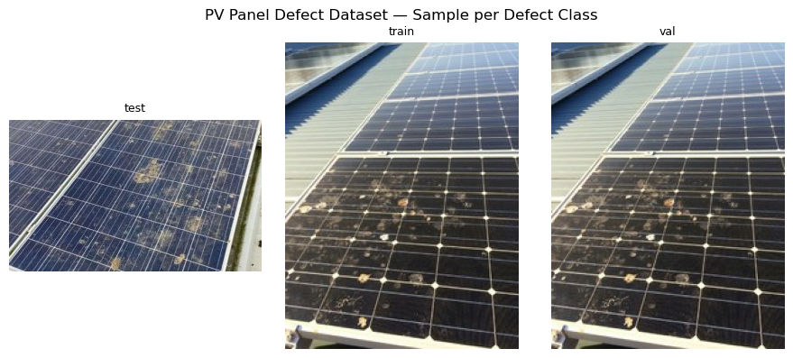

```python
display_classes = sorted(defect_counts.keys())[:6]
fig, axes = plt.subplots(1, len(display_classes), figsize=(3 * len(display_classes), 4))
if len(display_classes) == 1:
    axes = [axes]

for ax, cls in zip(axes, display_classes):
    class_dir = Path(pv_defect_path) / cls
    imgs = [f for f in class_dir.rglob('*') if f.suffix.lower() in IMAGE_EXTENSIONS]
    if imgs:
        ax.imshow(mpimg.imread(str(imgs[0])))
        ax.set_title(cls, fontsize=9)
        ax.axis('off')

plt.suptitle('PV Panel Defect Dataset — Sample per Defect Class', fontsize=12)
plt.tight_layout()
plt.savefig('/tmp/pv_defect_samples.png', dpi=150)
plt.show()
```

## 4. Full EDA Summary

```python
print('=' * 62)
print('       SOLARIS ANALYTICS — COMPLETE EDA SUMMARY')
print('=' * 62)

print(f'\n[1] NSRDB Houston Solar Irradiance (2000-2019)')
print(f'    Rows:       {len(nsrdb_df):,}')
print(f'    Columns:    {nsrdb_df.shape[1]}')
print(f'    Date Range: {nsrdb_df["Timestamp"].min()} to {nsrdb_df["Timestamp"].max()}')
print(f'    Missing:    {nsrdb_df.isnull().sum().sum()}')
print(f'    GHI Range:  {nsrdb_df["GHI"].min()} - {nsrdb_df["GHI"].max()} W/m2')
print(f'    Key Risk:   U.S.-centric (Houston only); seasonal/diurnal bias expected')

print(f'\n[2] GPVS-Faults Sensor Data')
print(f'    Rows:       {len(gpvs_df):,}')
print(f'    Columns:    {gpvs_df.shape[1]}')
print(f'    Missing:    {gpvs_df.isnull().sum().sum()}')
print(f'    Key Risk:   Single PV system source; check fault class imbalance')

print(f'\n[3] Solar Panel Images (pythonafroz) — Binary Classification')
for cls, cnt in sorted(solar_counts.items()):
    print(f'    {cls}: {cnt} images')
print(f'    Total: {sum(solar_counts.values())} | Key Risk: Binary class balance')

print(f'\n[4] PV Panel Defect Dataset (alicjalena) — Multi-class (6 classes)')
for cls, cnt in sorted(defect_counts.items()):
    print(f'    {cls}: {cnt} images')
print(f'    Total: {sum(defect_counts.values())} | Key Risk: Multi-class imbalance')

print(f'\nAll data stored at: s3://{BUCKET}/')
print(f'  nsrdb/                          <- NREL irradiance CSV')
print(f'  gpvs-faults/                    <- PV sensor fault CSV')
print(f'  panel-images/solar-panel-images/ <- pythonafroz images')
print(f'  panel-images/pv-defect/          <- alicjalena images')
print(f'\nGitHub: https://github.com/darth-franky/Applied-Data-Science/tree/main/ADS508')
print('=' * 62)
```

[output not shown]

## 2. Data Scrubbing — NSRDB Irradiance

**Cleansing steps applied:**

- No missing values found in EDA — confirmed below
- Remove physically impossible values (negative irradiance)
- Filter to daytime only (GHI > 0) for forecasting model
- Extract temporal features from Timestamp

```python
print(f'NSRDB rows (raw): {len(nsrdb_df):,}')
print(f'Missing values:   {nsrdb_df.isnull().sum().sum()}')

# Remove negative irradiance (physically impossible)
nsrdb_clean = nsrdb_df.copy()
for col in ['GHI', 'DNI', 'DHI']:
    nsrdb_clean = nsrdb_clean[nsrdb_clean[col] >= 0]

# Filter to daytime only for forecasting (nighttime GHI=0 adds noise)
nsrdb_daytime = nsrdb_clean[nsrdb_clean['GHI'] > 0].copy()

print(f'After cleaning:   {len(nsrdb_clean):,} rows')
print(f'Daytime only:     {len(nsrdb_daytime):,} rows')
print(f'Nighttime removed:{len(nsrdb_clean) - len(nsrdb_daytime):,} rows')
```

```
NSRDB rows (raw): 350,640
Missing values:   0
After cleaning:   350,640 rows
Daytime only:     175,131 rows
Nighttime removed:175,509 rows
```

### 2.1 NSRDB — Feature Engineering

**Feature creation:** Extract temporal features from Timestamp and apply cyclical encoding to preserve periodicity (month 12 → month 1, hour 23 → hour 0).  
**Feature selection:** Use DNI, DHI, Temperature, Wind_Speed + engineered temporal features. Exclude raw Timestamp, Month, Hour (replaced by cyclical versions).

```python
nsrdb_daytime['Month']     = nsrdb_daytime['Timestamp'].dt.month
nsrdb_daytime['Hour']      = nsrdb_daytime['Timestamp'].dt.hour
nsrdb_daytime['DayOfYear'] = nsrdb_daytime['Timestamp'].dt.dayofyear

# Cyclical encoding — prevents model from treating Dec->Jan as a large jump
nsrdb_daytime['Month_sin'] = np.sin(2 * np.pi * nsrdb_daytime['Month'] / 12)
nsrdb_daytime['Month_cos'] = np.cos(2 * np.pi * nsrdb_daytime['Month'] / 12)
nsrdb_daytime['Hour_sin']  = np.sin(2 * np.pi * nsrdb_daytime['Hour'] / 24)
nsrdb_daytime['Hour_cos']  = np.cos(2 * np.pi * nsrdb_daytime['Hour'] / 24)

# GHI category buckets (Low/Medium/High) per design doc
nsrdb_daytime['GHI_Category'] = pd.cut(
    nsrdb_daytime['GHI'],
    bins=[0, 200, 600, nsrdb_daytime['GHI'].max() + 1],
    labels=[0, 1, 2]  # 0=Low, 1=Medium, 2=High
).astype(int)

print('GHI Category distribution (daytime):')
print(nsrdb_daytime['GHI_Category'].value_counts().sort_index())
print('\n0=Low (<200), 1=Medium (200-600), 2=High (>600)')
```

```
GHI Category distribution (daytime):
GHI_Category
0    57143
1    67793
2    50195
Name: count, dtype: int64

0=Low (<200), 1=Medium (200-600), 2=High (>600)
```

### 2.2 NSRDB — Feature Selection & Scaling

```python
# Features: physical weather + cyclical temporal
NSRDB_FEATURES = ['DNI', 'DHI', 'Temperature', 'Wind_Speed',
                  'Month_sin', 'Month_cos', 'Hour_sin', 'Hour_cos', 'DayOfYear']
NSRDB_TARGET   = 'GHI'

X_nsrdb = nsrdb_daytime[NSRDB_FEATURES]
y_nsrdb = nsrdb_daytime[NSRDB_TARGET]

scaler_nsrdb   = StandardScaler()
X_nsrdb_scaled = pd.DataFrame(
    scaler_nsrdb.fit_transform(X_nsrdb),
    columns=NSRDB_FEATURES
)

print(f'Features: {NSRDB_FEATURES}')
print(f'Target:   {NSRDB_TARGET}')
print(f'Shape:    {X_nsrdb_scaled.shape}')
```

```
Features: ['DNI', 'DHI', 'Temperature', 'Wind_Speed', 'Month_sin', 'Month_cos', 'Hour_sin', 'Hour_cos', 'DayOfYear']
Target:   GHI
Shape:    (175131, 9)
```

### 2.3 NSRDB — Train / Validation / Test Split (70/15/15)

```python
X_train_n, X_temp_n, y_train_n, y_temp_n = train_test_split(
    X_nsrdb_scaled, y_nsrdb, test_size=0.30, random_state=42)
X_val_n, X_test_n, y_val_n, y_test_n = train_test_split(
    X_temp_n, y_temp_n, test_size=0.50, random_state=42)

total = len(X_nsrdb_scaled)
print('NSRDB Split:')
print(f'  Train:      {len(X_train_n):,} ({len(X_train_n)/total*100:.1f}%)')
print(f'  Validation: {len(X_val_n):,} ({len(X_val_n)/total*100:.1f}%)')
print(f'  Test:       {len(X_test_n):,} ({len(X_test_n)/total*100:.1f}%)')
```

```
NSRDB Split:
  Train:      122,591 (70.0%)
  Validation: 26,270 (15.0%)
  Test:       26,270 (15.0%)
```

## 3. Data Scrubbing — GPVS Fault Sensor Data

**Key findings from EDA:**

- 16 scenario files (F0L, F0M ... F7L, F7M) — fault type encoded in filename
- Actual sensor columns: `Ipv, Vpv, Vdc, ia, ib, ic, va, vb, vc, Iabc, If, Vabc, Vf`
- `Time` is a relative timestamp within each scenario, not a real datetime
- GHI/DNI/DHI/Timestamp columns present from accidental merge — **excluded**

**Cleansing steps:**

- Drop accidental NSRDB columns
- Drop rows with missing sensor values
- Use `fault_type` (F0–F7) as classification target — 8 classes

```python
print(f'GPVS rows (raw): {len(gpvs_df):,}')
print(f'Columns: {gpvs_df.columns.tolist()}')

# Drop columns that came from the accidental NSRDB merge
accidental_cols = ['Timestamp', 'GHI', 'DNI', 'DHI', 'Temperature', 'Wind_Speed', 'source_file']
accidental_cols = [c for c in accidental_cols if c in gpvs_df.columns]
gpvs_clean = gpvs_df.drop(columns=accidental_cols).copy()
print(f'\nDropped accidental columns: {accidental_cols}')
print(f'Remaining columns: {gpvs_clean.columns.tolist()}')
```

```
GPVS rows (raw): 2,514,120
Columns: ['Time', 'Ipv', 'Vpv', 'Vdc', 'ia', 'ib', 'ic', 'va', 'vb', 'vc', 'Iabc', 'If', 'Vabc', 'Vf', 'source_file', 'Timestamp', 'GHI', 'DNI', 'DHI', 'Temperature', 'Wind_Speed']

Dropped accidental columns: ['Timestamp', 'GHI', 'DNI', 'DHI', 'Temperature', 'Wind_Speed', 'source_file']
Remaining columns: ['Time', 'Ipv', 'Vpv', 'Vdc', 'ia', 'ib', 'ic', 'va', 'vb', 'vc', 'Iabc', 'If', 'Vabc', 'Vf']
```

```python
local_gpvs_dir = '/home/sagemaker-user/dataset2/gpvs-faults/'
csv_files = list(Path(local_gpvs_dir).glob('*.csv'))

# Columns that don't belong in GPVS data
ACCIDENTAL_COLS = ['Timestamp', 'GHI', 'DNI', 'DHI', 'Temperature', 'Wind_Speed', 'source_file']

dfs = []
for f in csv_files:
    df_temp = pd.read_csv(f)
    df_temp = df_temp.drop(columns=[c for c in ACCIDENTAL_COLS if c in df_temp.columns])
    df_temp['scenario']       = f.stem
    df_temp['fault_type']     = f.stem[:-1]
    df_temp['fault_severity'] = f.stem[-1]
    dfs.append(df_temp)

gpvs_df    = pd.concat(dfs, ignore_index=True)
gpvs_clean = gpvs_df.dropna().copy()

print(f'GPVS loaded:  {gpvs_df.shape}')
print(f'GPVS cleaned: {gpvs_clean.shape}')
print(f'Fault types:  {sorted(gpvs_clean["fault_type"].unique())}')
```

```
GPVS loaded:  (2514120, 17)
GPVS cleaned: (2163480, 17)
Fault types:  ['F0', 'F1', 'F2', 'F3', 'F4', 'F5', 'F6', 'F7']
```

### 3.1 GPVS — Feature Selection

**Selected features:** Core electrical sensor readings: `Ipv, Vpv, Vdc, ia, ib, ic, va, vb, vc, Iabc, If, Vabc, Vf`  
**Excluded:** `Time` (relative timestamp, not a real feature), `scenario`, `fault_severity` (keep only fault type as target)  
**Target:** `fault_type` (F0–F7, 8 classes)

```python
GPVS_SENSOR_COLS = ['Ipv', 'Vpv', 'Vdc', 'ia', 'ib', 'ic',
                    'va', 'vb', 'vc', 'Iabc', 'If', 'Vabc', 'Vf']

# Verify all expected columns exist
missing_cols = [c for c in GPVS_SENSOR_COLS if c not in gpvs_clean.columns]
if missing_cols:
    print(f'WARNING: Missing columns: {missing_cols}')
    GPVS_SENSOR_COLS = [c for c in GPVS_SENSOR_COLS if c in gpvs_clean.columns]

GPVS_TARGET = 'fault_type'

# Encode fault_type labels (F0–F7 -> 0–7)
le = LabelEncoder()
gpvs_clean['fault_label'] = le.fit_transform(gpvs_clean[GPVS_TARGET])

print(f'Sensor features: {GPVS_SENSOR_COLS}')
print(f'Target:          {GPVS_TARGET}')
print(f'Label encoding:  {dict(zip(le.classes_, le.transform(le.classes_)))}')
print(f'\nClass distribution:')
print(gpvs_clean['fault_label'].value_counts().sort_index())
```

```
Sensor features: ['Ipv', 'Vpv', 'Vdc', 'ia', 'ib', 'ic', 'va', 'vb', 'vc', 'Iabc', 'If', 'Vabc', 'Vf']
Target:          fault_type
Label encoding:  {'F0': 0, 'F1': 1, 'F2': 2, 'F3': 3, 'F4': 4, 'F5': 5, 'F6': 6, 'F7': 7}

Class distribution:
fault_label
0    284729
1    268027
2    286143
3    173464
4    288028
5    287029
6    288030
7    288030
Name: count, dtype: int64
```

### 3.2 GPVS — Scale Features

```python
X_gpvs = gpvs_clean[GPVS_SENSOR_COLS]
y_gpvs = gpvs_clean['fault_label']

scaler_gpvs   = StandardScaler()
X_gpvs_scaled = pd.DataFrame(
    scaler_gpvs.fit_transform(X_gpvs),
    columns=GPVS_SENSOR_COLS
)

print(f'Scaled feature matrix: {X_gpvs_scaled.shape}')
```

```
Scaled feature matrix: (2163480, 13)
```

### 3.3 GPVS — Balance Classes with SMOTE

Class imbalance check from EDA showed uneven scenario sizes (F3M had only 69,967 rows vs 144,015 for others). SMOTE applied to balance before splitting.

```
Class distribution BEFORE SMOTE:
fault_label
0    284729
1    268027
2    286143
3    173464
4    288028
5    287029
6    288030
7    288030
Name: count, dtype: int64

Dataset large (2,163,480 rows). Sampling 500,000 rows for SMOTE...

Class distribution AFTER SMOTE:
  F0 (class 0): 66,712
  F1 (class 1): 66,712
  F2 (class 2): 66,712
  F3 (class 3): 66,712
  F4 (class 4): 66,712
  F5 (class 5): 66,712
  F6 (class 6): 66,712
  F7 (class 7): 66,712
```

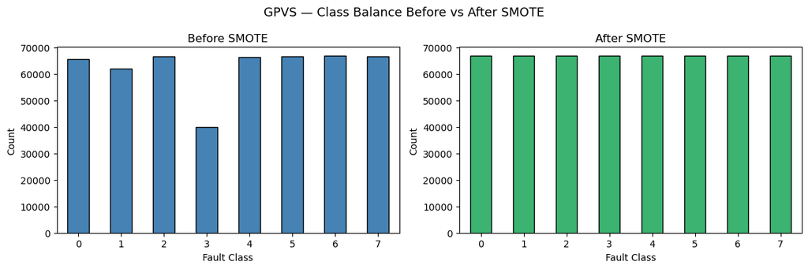

```python
print('Class distribution BEFORE SMOTE:')
print(y_gpvs.value_counts().sort_index())


MAX_ROWS = 500_000
if len(X_gpvs_scaled) > MAX_ROWS:
    print(f'\nDataset large ({len(X_gpvs_scaled):,} rows). Sampling {MAX_ROWS:,} rows for SMOTE...')
    sample_idx = np.random.choice(len(X_gpvs_scaled), MAX_ROWS, replace=False)
    X_sample = X_gpvs_scaled.iloc[sample_idx]
    y_sample = y_gpvs.iloc[sample_idx]
else:
    X_sample = X_gpvs_scaled
    y_sample = y_gpvs

smote = SMOTE(random_state=42)
X_gpvs_balanced, y_gpvs_balanced = smote.fit_resample(X_sample, y_sample)

print(f'\nClass distribution AFTER SMOTE:')
unique, counts = np.unique(y_gpvs_balanced, return_counts=True)
for u, c in zip(unique, counts):
    print(f'  {le.inverse_transform([u])[0]} (class {u}): {c:,}')

# Plot before/after
fig, axes = plt.subplots(1, 2, figsize=(12, 4))
pd.Series(y_sample.values).value_counts().sort_index().plot(
    kind='bar', ax=axes[0], color='steelblue', edgecolor='black', title='Before SMOTE')
pd.Series(y_gpvs_balanced).value_counts().sort_index().plot(
    kind='bar', ax=axes[1], color='mediumseagreen', edgecolor='black', title='After SMOTE')
for ax in axes:
    ax.set_xlabel('Fault Class')
    ax.set_ylabel('Count')
    ax.tick_params(axis='x', rotation=0)
plt.suptitle('GPVS — Class Balance Before vs After SMOTE', fontsize=13)
plt.tight_layout()
plt.savefig('/home/sagemaker-user/dataset1/gpvs_smote_balance.png', dpi=150)
plt.show()
```

### 3.4 GPVS — Train / Validation / Test Split (70/15/15)

```python
X_train_g, X_temp_g, y_train_g, y_temp_g = train_test_split(
    X_gpvs_balanced, y_gpvs_balanced,
    test_size=0.30, random_state=42, stratify=y_gpvs_balanced)
X_val_g, X_test_g, y_val_g, y_test_g = train_test_split(
    X_temp_g, y_temp_g,
    test_size=0.50, random_state=42, stratify=y_temp_g)

print('GPVS Split:')
print(f'  Train:      {len(X_train_g):,}')
print(f'  Validation: {len(X_val_g):,}')
print(f'  Test:       {len(X_test_g):,}')
```

```
GPVS Split:
  Train:      373,587
  Validation: 80,054
  Test:       80,055
```

## 4. Save Prepared Data to S3

All splits saved as headerless CSV under `s3://solaris-analytics-bucket/prepared/`  
*(SageMaker built-in algorithms expect target as first column, no header)*

```python
prepared_dir = '/home/sagemaker-user/dataset1/prepared/'
os.makedirs(prepared_dir, exist_ok=True)

def save_and_upload(X, y, name, target_col):
    df = X.copy()
    y_vals = y.values if hasattr(y, 'values') else np.array(y)
    df.insert(0, target_col, y_vals)  # target must be first column
    local_path = os.path.join(prepared_dir, f'{name}.csv')
    df.to_csv(local_path, index=False, header=False)
    s3_key = f'prepared/{name}.csv'
    s3.upload_file(local_path, BUCKET, s3_key)
    print(f'Uploaded {name}.csv  ({len(df):,} rows)  ->  s3://{BUCKET}/{s3_key}')
    return f's3://{BUCKET}/{s3_key}'

# NSRDB irradiance splits
nsrdb_train_uri = save_and_upload(X_train_n, y_train_n, 'nsrdb_train', 'GHI')
nsrdb_val_uri   = save_and_upload(X_val_n,   y_val_n,   'nsrdb_val',   'GHI')
nsrdb_test_uri  = save_and_upload(X_test_n,  y_test_n,  'nsrdb_test',  'GHI')

# GPVS fault classification splits
gpvs_train_uri  = save_and_upload(X_train_g, y_train_g, 'gpvs_train', 'fault_label')
gpvs_val_uri    = save_and_upload(X_val_g,   y_val_g,   'gpvs_val',   'fault_label')
gpvs_test_uri   = save_and_upload(X_test_g,  y_test_g,  'gpvs_test',  'fault_label')

print('\nAll prepared datasets uploaded to S3.')
```

```
Uploaded nsrdb_train.csv  (122,591 rows)  ->  s3://solaris-analytics-bucket/prepared/nsrdb_train.csv
Uploaded nsrdb_val.csv  (26,270 rows)  ->  s3://solaris-analytics-bucket/prepared/nsrdb_val.csv
Uploaded nsrdb_test.csv  (26,270 rows)  ->  s3://solaris-analytics-bucket/prepared/nsrdb_test.csv
Uploaded gpvs_train.csv  (373,587 rows)  ->  s3://solaris-analytics-bucket/prepared/gpvs_train.csv
Uploaded gpvs_val.csv  (80,054 rows)  ->  s3://solaris-analytics-bucket/prepared/gpvs_val.csv
Uploaded gpvs_test.csv  (80,055 rows)  ->  s3://solaris-analytics-bucket/prepared/gpvs_test.csv

All prepared datasets uploaded to S3.
```

## 5. Model Training — XGBoost for Fault Classification (GPVS)

**Task:** Classify fault type (F0–F7) from electrical sensor readings  
**Algorithm:** SageMaker built-in XGBoost  
**Target metric:** Weighted F1-score > 0.85

```python
num_classes   = len(le.classes_)
xgb_image_uri = image_uris.retrieve('xgboost', REGION, version='1.7-1')
print(f'XGBoost image: {xgb_image_uri}')
print(f'Classes: {num_classes} ({list(le.classes_)})')

xgb_estimator = Estimator(
    image_uri         = xgb_image_uri,
    role              = role,
    instance_count    = 1,
    instance_type     = 'ml.m5.xlarge',
    output_path       = f's3://{BUCKET}/models/xgboost/',
    sagemaker_session = session
)

xgb_estimator.set_hyperparameters(
    objective        = 'multi:softmax',
    num_class        = num_classes,
    num_round        = 100,
    max_depth        = 6,
    eta              = 0.2,
    subsample        = 0.8,
    colsample_bytree = 0.8,
    eval_metric      = 'merror'
)

xgb_estimator.fit(
    inputs={
        'train':      TrainingInput(gpvs_train_uri, content_type='text/csv'),
        'validation': TrainingInput(gpvs_val_uri,   content_type='text/csv')
    },
    wait=True
)
print('XGBoost training complete.')
```

```
INFO:sagemaker:Creating training-job with name: sagemaker-xgboost-2026-03-22-23-33-49-181
```

[output not shown]

[output cut: 90 more lines]

```
[91]#011train-merror:0.03550#011validation-merror:0.04237
[92]#011train-merror:0.03522#011validation-merror:0.04230
[93]#011train-merror:0.03468#011validation-merror:0.04206
[94]#011train-merror:0.03446#011validation-merror:0.04172
[95]#011train-merror:0.03413#011validation-merror:0.04137
[96]#011train-merror:0.03370#011validation-merror:0.04118
[97]#011train-merror:0.03334#011validation-merror:0.04082

2026-03-22 23:39:48 Uploading - Uploading generated training model[98]#011train-merror:0.03289#011validation-merror:0.04030
[99]#011train-merror:0.03244#011validation-merror:0.03994

2026-03-22 23:40:01 Completed - Training job completed
Training seconds: 335
Billable seconds: 335
XGBoost training complete.
```

### 5.1 XGBoost — Evaluate on Test Set

```
INFO:sagemaker:Creating model with name: sagemaker-xgboost-2026-03-22-23-40-40-565
INFO:sagemaker:Creating endpoint-config with name sagemaker-xgboost-2026-03-22-23-40-40-565
INFO:sagemaker:Creating endpoint with name sagemaker-xgboost-2026-03-22-23-40-40-565
```

```
------!=== XGBoost Fault Classification Results ===
Weighted F1-Score: 0.9598  (target > 0.85)
Target Met: YES ✓

Classification Report:
              precision    recall  f1-score   support

          F0       0.94      0.95      0.95     10007
          F1       0.98      0.98      0.98     10006
          F2       0.98      0.97      0.98     10007
          F3       0.93      0.94      0.93     10007
          F4       1.00      1.00      1.00     10007
          F5       0.96      0.93      0.95     10007
          F6       0.95      0.96      0.96     10007
          F7       0.94      0.93      0.93     10007

    accuracy                           0.96     80055
   macro avg       0.96      0.96      0.96     80055
weighted avg       0.96      0.96      0.96     80055
```

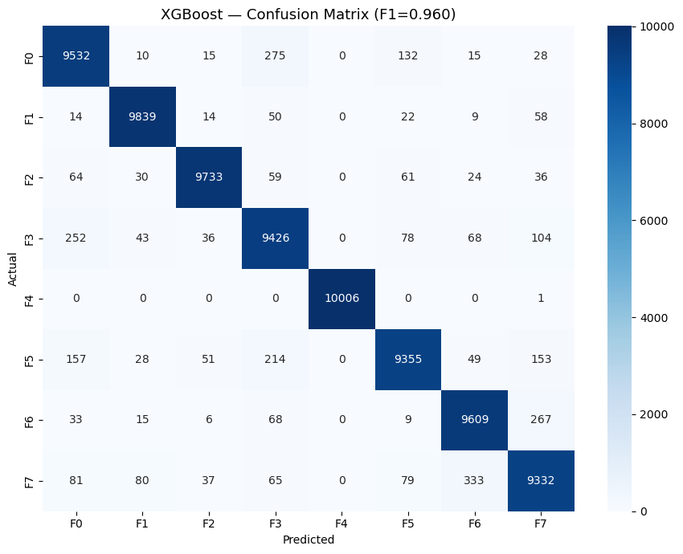

```
INFO:sagemaker:Deleting endpoint configuration with name: sagemaker-xgboost-2026-03-22-23-40-40-565
INFO:sagemaker:Deleting endpoint with name: sagemaker-xgboost-2026-03-22-23-40-40-565
```

```
Endpoint deleted.
```

```python
xgb_predictor = xgb_estimator.deploy(
    initial_instance_count=1,
    instance_type='ml.m5.xlarge',
    serializer=CSVSerializer()
)

def predict_batches(predictor, X, batch_size=500):
    preds = []
    for i in range(0, len(X), batch_size):
        batch  = X.iloc[i:i+batch_size] if hasattr(X, 'iloc') else X[i:i+batch_size]
        result = predictor.predict(batch.values if hasattr(batch, 'values') else batch)
        preds.extend([float(x) for x in result.decode('utf-8').strip().split('\n')])
    return np.array(preds)

y_pred_g = predict_batches(xgb_predictor, X_test_g)
f1 = f1_score(y_test_g, y_pred_g, average='weighted')

print('=== XGBoost Fault Classification Results ===')
print(f'Weighted F1-Score: {f1:.4f}  (target > 0.85)')
print(f'Target Met: {"YES ✓" if f1 > 0.85 else "NO — consider tuning hyperparameters"}')
print(f'\nClassification Report:')
print(classification_report(y_test_g, y_pred_g, target_names=le.classes_))

fig, ax = plt.subplots(figsize=(9, 7))
cm = confusion_matrix(y_test_g, y_pred_g)
sns.heatmap(cm, annot=True, fmt='d', cmap='Blues', ax=ax,
            xticklabels=le.classes_, yticklabels=le.classes_)
ax.set_title(f'XGBoost — Confusion Matrix (F1={f1:.3f})', fontsize=13)
ax.set_xlabel('Predicted')
ax.set_ylabel('Actual')
plt.tight_layout()
plt.savefig('/home/sagemaker-user/dataset1/xgb_confusion_matrix.png', dpi=150)
plt.show()

xgb_predictor.delete_endpoint()
print('Endpoint deleted.')
```

## 6. Model Training — Linear Learner for Irradiance Forecasting (NSRDB)

**Task:** Predict GHI solar irradiance from weather + temporal features  
**Algorithm:** SageMaker built-in Linear Learner (regression)  
**Target metric:** 20% RMSE reduction over historical average baseline

```python
baseline_pred = np.full(len(y_test_n), y_train_n.mean())
baseline_rmse = np.sqrt(mean_squared_error(y_test_n, baseline_pred))
target_rmse   = baseline_rmse * 0.80

print(f'Baseline RMSE (historical mean): {baseline_rmse:.4f} W/m2')
print(f'Target RMSE  (20% reduction):    {target_rmse:.4f} W/m2')
```

```
Baseline RMSE (historical mean): 290.4492 W/m2
Target RMSE  (20% reduction):    232.3594 W/m2
```

```python
ll_image_uri = image_uris.retrieve('linear-learner', REGION)
print(f'Linear Learner image: {ll_image_uri}')

ll_estimator = Estimator(
    image_uri         = ll_image_uri,
    role              = role,
    instance_count    = 1,
    instance_type     = 'ml.m5.xlarge',
    output_path       = f's3://{BUCKET}/models/linear-learner/',
    sagemaker_session = session
)

ll_estimator.set_hyperparameters(
    predictor_type  = 'regressor',
    mini_batch_size = 200,
    epochs          = 15,
    learning_rate   = 'auto',
    loss            = 'squared_loss',
    normalize_data  = True
)

ll_estimator.fit(
    inputs={
        'train':      TrainingInput(nsrdb_train_uri, content_type='text/csv'),
        'validation': TrainingInput(nsrdb_val_uri,   content_type='text/csv')
    },
    wait=True
)
print('Linear Learner training complete.')
```

```
INFO:sagemaker.image_uris:Same images used for training and inference. Defaulting to image scope: inference.
INFO:sagemaker.image_uris:Ignoring unnecessary instance type: None.
INFO:sagemaker.telemetry.telemetry_logging:SageMaker Python SDK will collect telemetry to help us better understand our user's needs, diagnose issues, and deliver additional features.
To opt out of telemetry, please disable via TelemetryOptOut parameter in SDK defaults config. For more information, refer to https://sagemaker.readthedocs.io/en/stable/overview.html#configuring-and-using-defaults-with-the-sagemaker-python-sdk.
INFO:sagemaker:Creating training-job with name: linear-learner-2026-03-22-23-44-21-034
```

[output not shown]

[output cut: 439 more lines]

```
[03/22/2026 23:47:47 INFO 139950999783232] #quality_metric: host=algo-1, validation mse_objective <loss>=6003.574281499809
[03/22/2026 23:47:47 INFO 139950999783232] #quality_metric: host=algo-1, validation mse <loss>=6003.574281499809
[03/22/2026 23:47:47 INFO 139950999783232] #quality_metric: host=algo-1, validation absolute_loss <loss>=62.940420412572564
[03/22/2026 23:47:47 INFO 139950999783232] #quality_metric: host=algo-1, validation rmse <loss>=77.48273537698452
[03/22/2026 23:47:47 INFO 139950999783232] #quality_metric: host=algo-1, validation r2 <loss>=0.9280900461820392
[03/22/2026 23:47:47 INFO 139950999783232] #quality_metric: host=algo-1, validation mae <loss>=62.940420328350086
[03/22/2026 23:47:47 INFO 139950999783232] Best model found for hyperparameters: {"optimizer": "adam", "learning_rate": 0.005, "l1": 0.0, "wd": 0.0001, "lr_scheduler_step": 10, "lr_scheduler_factor": 0.99, "lr_scheduler_minimum_lr": 1e-05}
[03/22/2026 23:47:47 INFO 139950999783232] Saved checkpoint to "/tmp/tmpzgjo3qxz/mx-mod-0000.params"
[03/22/2026 23:47:47 INFO 139950999783232] Test data is not provided.
#metrics {"StartTime": 1774223197.8058407, "EndTime": 1774223267.615863, "Dimensions": {"Algorithm": "Linear Learner", "Host": "algo-1", "Operation": "training"}, "Metrics": {"initialize.time": {"sum": 463.0467891693115, "count": 1, "min": 463.0467891693115, "max": 463.0467891693115}, "epochs": {"su…

2026-03-22 23:48:08 Completed - Training job completed
Training seconds: 190
Billable seconds: 190
Linear Learner training complete.
```

### 6.1 Linear Learner — Evaluate on Test Set

```
INFO:sagemaker:Creating model with name: linear-learner-2026-03-22-23-48-40-010
INFO:sagemaker:Creating endpoint-config with name linear-learner-2026-03-22-23-48-40-010
INFO:sagemaker:Creating endpoint with name linear-learner-2026-03-22-23-48-40-010
```

```
------!=== Linear Learner Irradiance Forecasting Results ===
Baseline RMSE:  290.4492 W/m2
Model RMSE:     76.8173 W/m2
RMSE Reduction: 73.6%  (target >= 20%)
Target Met: YES ✓
```

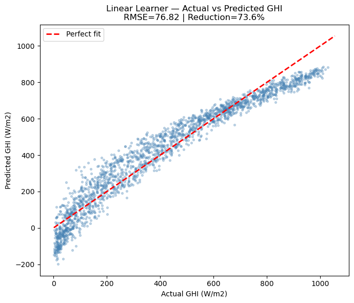

```
INFO:sagemaker:Deleting endpoint configuration with name: linear-learner-2026-03-22-23-48-40-010
INFO:sagemaker:Deleting endpoint with name: linear-learner-2026-03-22-23-48-40-010
```

```
Endpoint deleted.
```

```python
ll_predictor = ll_estimator.deploy(
    initial_instance_count=1,
    instance_type='ml.m5.xlarge',
    serializer=CSVSerializer()
)

def predict_regression_batches(predictor, X, batch_size=500):
    preds = []
    for i in range(0, len(X), batch_size):
        batch  = X.iloc[i:i+batch_size]
        result = predictor.predict(batch.values)
        parsed = json.loads(result)
        preds.extend([p['score'] for p in parsed['predictions']])
    return np.array(preds)

y_pred_n   = predict_regression_batches(ll_predictor, X_test_n)
model_rmse = np.sqrt(mean_squared_error(y_test_n, y_pred_n))
rmse_pct   = (baseline_rmse - model_rmse) / baseline_rmse * 100

print('=== Linear Learner Irradiance Forecasting Results ===')
print(f'Baseline RMSE:  {baseline_rmse:.4f} W/m2')
print(f'Model RMSE:     {model_rmse:.4f} W/m2')
print(f'RMSE Reduction: {rmse_pct:.1f}%  (target >= 20%)')
print(f'Target Met: {"YES ✓" if rmse_pct >= 20 else "NO — consider XGBoost regressor or more features"}')

fig, ax = plt.subplots(figsize=(7, 6))
sample = min(2000, len(y_test_n))
ax.scatter(y_test_n.values[:sample], y_pred_n[:sample], alpha=0.3, s=8, color='steelblue')
ax.plot([y_test_n.min(), y_test_n.max()],
        [y_test_n.min(), y_test_n.max()], 'r--', lw=2, label='Perfect fit')
ax.set_xlabel('Actual GHI (W/m2)')
ax.set_ylabel('Predicted GHI (W/m2)')
ax.set_title(f'Linear Learner — Actual vs Predicted GHI\nRMSE={model_rmse:.2f} | Reduction={rmse_pct:.1f}%')
ax.legend()
plt.tight_layout()
plt.savefig('/home/sagemaker-user/dataset1/ll_actual_vs_predicted.png', dpi=150)
plt.show()

ll_predictor.delete_endpoint()
print('Endpoint deleted.')
```

## 7. Final Summary

```python
print('=' * 62)
print('    SOLARIS ANALYTICS — DATA PREP & TRAINING SUMMARY')
print('=' * 62)

print('\n[DATA PREPARATION — NSRDB]')
print(f'  Raw rows:              {len(nsrdb_df):,}')
print(f'  Cleaned (daytime):     {len(nsrdb_daytime):,}')
print(f'  Features:              {NSRDB_FEATURES}')
print(f'  Target:                GHI (continuous)')
print(f'  Scaling:               StandardScaler')
print(f'  Split:                 70/15/15')
print(f'  Train: {len(X_train_n):,} | Val: {len(X_val_n):,} | Test: {len(X_test_n):,}')

print('\n[DATA PREPARATION — GPVS]')
print(f'  Raw rows:              {len(gpvs_df):,}')
print(f'  After cleaning:        {len(gpvs_clean):,}')
print(f'  After SMOTE:           {len(X_gpvs_balanced):,}')
print(f'  Features:              {GPVS_SENSOR_COLS}')
print(f'  Target:                fault_type (F0-F7, {num_classes} classes)')
print(f'  Balancing:             SMOTE')
print(f'  Scaling:               StandardScaler')
print(f'  Split:                 70/15/15 (stratified)')
print(f'  Train: {len(X_train_g):,} | Val: {len(X_val_g):,} | Test: {len(X_test_g):,}')

print('\n[MODEL RESULTS]')
print(f'  XGBoost F1-Score:      {f1:.4f}  (target > 0.85)')
print(f'  Linear Learner RMSE:   {model_rmse:.4f} W/m2')
print(f'  Baseline RMSE:         {baseline_rmse:.4f} W/m2')
print(f'  RMSE Reduction:        {rmse_pct:.1f}%  (target >= 20%)')

print(f'\nPrepared data: s3://{BUCKET}/prepared/')
print(f'Models:        s3://{BUCKET}/models/')
print(f'GitHub:        https://github.com/darth-franky/Applied-Data-Science/tree/main/ADS508')
print('=' * 62)
```

```
==============================================================
    SOLARIS ANALYTICS — DATA PREP & TRAINING SUMMARY
==============================================================

[DATA PREPARATION — NSRDB]
  Raw rows:              350,640
  Cleaned (daytime):     175,131
  Features:              ['DNI', 'DHI', 'Temperature', 'Wind_Speed', 'Month_sin', 'Month_cos', 'Hour_sin', 'Hour_cos', 'DayOfYear']
  Target:                GHI (continuous)
  Scaling:               StandardScaler
  Split:                 70/15/15
  Train: 122,591 | Val: 26,270 | Test: 26,270

[DATA PREPARATION — GPVS]
  Raw rows:              2,514,120
  After cleaning:        2,163,480
  After SMOTE:           533,696
  Features:              ['Ipv', 'Vpv', 'Vdc', 'ia', 'ib', 'ic', 'va', 'vb', 'vc', 'Iabc', 'If', 'Vabc', 'Vf']
  Target:                fault_type (F0-F7, 8 classes)
  Balancing:             SMOTE
  Scaling:               StandardScaler
  Split:                 70/15/15 (stratified)
  Train: 373,587 | Val: 80,054 | Test: 80,055

[MODEL RESULTS]
  XGBoost F1-Score:      0.9598  (target > 0.85)
  Linear Learner RMSE:   76.8173 W/m2
  Baseline RMSE:         290.4492 W/m2
  RMSE Reduction:        73.6%  (target >= 20%)

Prepared data: s3://solaris-analytics-bucket/prepared/
Models:        s3://solaris-analytics-bucket/models/
GitHub:        https://github.com/darth-franky/Applied-Data-Science/tree/main/ADS508
==============================================================
```